# Análisis de la estabilidad de los centroides en K-Medias en presencia de correlación

Gustavo Rendón Vélez

Juan David Rivera Builes

Sandra Milena Berrio Berrio

Veronica Yohana Garzon Zuluaga

### Metodología

Se deberá desarrollar un experimento de simulación para analizar la estabilidad del algoritmo de K-Means. Para ello se proponen los siguientes pasos.

1. Simular tres grupos de distribuciones normales bivariadas independientes pero con traslape. Es decir que los miembros de cada grupo son $X\sim N_2(\mu_j,\Sigma_j)$, $j=1,2,3$.

En este caso se simulan 3 distribuciones bivariadas con $\rho=0$ para que sean independientes, pero con vectores de medias, $\underline{\mu_{1}}=\begin{bmatrix} 0.5\\1.5 \end{bmatrix}$, $\underline{\mu_{2}}=\begin{bmatrix} -2 \\ 2.5 \end{bmatrix}$ y $\underline{\mu_{1}}= \begin{bmatrix} 4 \\ 1.5 \end{bmatrix}$.

Graficamos los puntos en el espacio 2d con sus respectivas etiquetas de grupos.

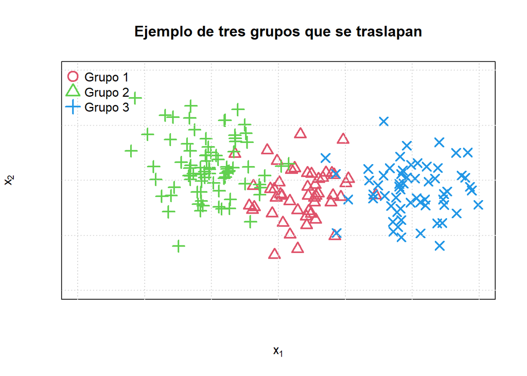

2. Encontrar los centroides con K-Means fijando el método de inicialización de los centroides. Encuentre los centroides para $n_c$ inicializaciones aleatorias.

Centroides con $n_{c}=10$ inicializaciones aleatorias y fijando una semilla.

```
##           X1       X2
## 1  0.6372389 1.542314
## 2 -2.2138899 2.567389
## 3  4.1170844 1.649207
```

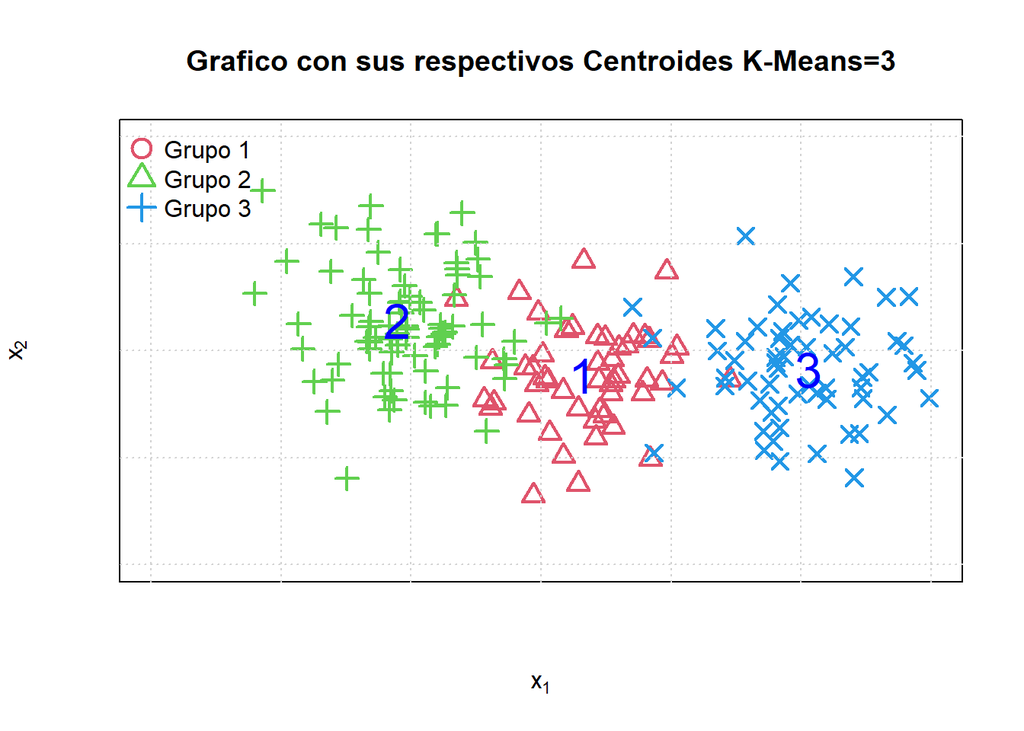

3. Suponga que el $i$-ésimo individuo es de la forma $X_i = [x_1^i \quad x_2^i]^T$. Cree la variable $x_3$ como $x_3^i=x_1^i+\epsilon_i$ con $\epsilon_i$ iid de media cero y varianza constante. ¿Cuál es la varianza de $x_3$? ¿Cuál es la covarianza entre $x_1$ y $x_3$? ¿Al agregar esta variable K-Means sigue detectando correctamente los centroides?

Simulamos y agregamos una semilla para un ruido normal con con $\mu=0$ y $\sigma=1$.

```r
set.seed(1234)
e <-rnorm(190,0,1)
muestra_nosep_df$X3 <- muestra_nosep_df$X1+e
```

Varianza de $x_3$

```
## [1] 8.931967
```

Covarianza de $x_1$ y $x_3$

```
## [1] 7.733793
```

Hallando de nuevo los centroides con $n_{c}=10$ inicializaciones aleatorias y $K=3$.

```
##           X1       X2         X3
## 1  0.5311224 1.552656  0.3046115
## 2 -2.2180296 2.577233 -2.3410554
## 3  4.0736868 1.659793  4.3182536
```

Graficamos de nuevo los puntos para $x_1$ y $x_2$ y sus respectivos centroides.

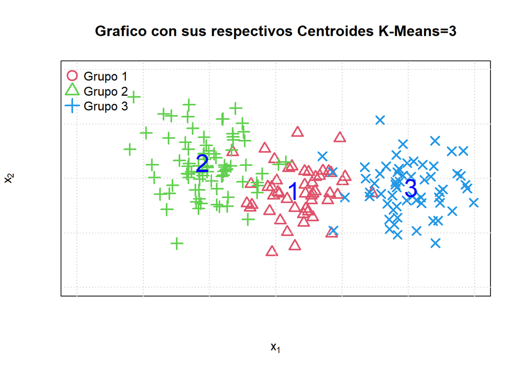

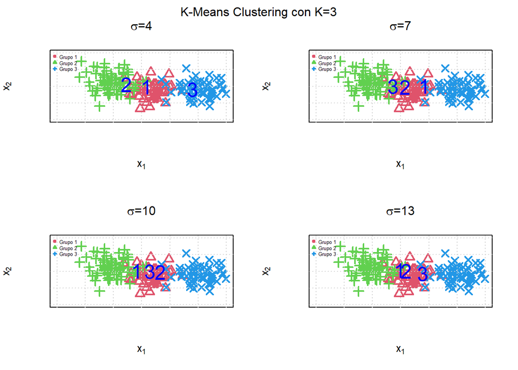

¿Qué pasa con la estabilidad de los centroides cuando la varianza de $\epsilon$ aumenta?

Se observa con cada iteración o aumento de $\sigma$ que los centroides cada vez son más inestables, agrupándose uno más cerca del otro a medida que la varianza de $\epsilon$ crece.

#### Grafica de varianza intre-grupos

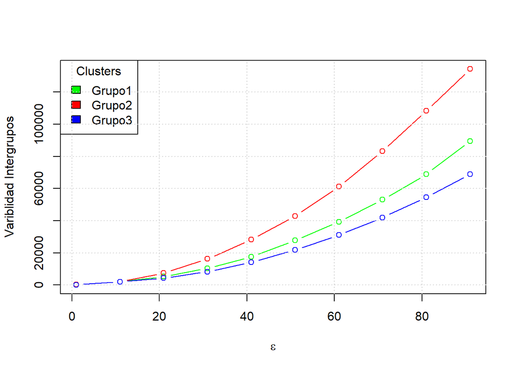

De forma iterativa se puede observar que a medida $\epsilon$ aumenta la variabilidad intra-cluster o dentro de los mismos grupos aumenta, un valor pequeño de esta medida es un indicador de alta estabilidad mientras una varianza grande indica baja o poca estabilidad como se puede observar en la gráfica anterior.

4. Creamos las variables $X_4$, y $X_6$

Como en el paso anterior, cree las variables $x_4$ y $x_6$ como la suma de $x_2$ y otra variable de media cero y varianza constante y la variable $x_5$ como la suma de $x_3$ y otra variable de media cero y varianza constante. ¿Al agregar estas variables, K-Means sigue detectando correctamente los centroides? ¿Qué pasa cuando la estabilidad de los centroides cuando la varianza de las variables que se suman a las variables originales aumenta?

```r
set.seed(123)
e4 <-rnorm(190,0,3)
e5 <-rnorm(190,0,9)
e6 <-rnorm(190,0,6)

muestra_nosep_df$X4 <- muestra_nosep_df$X2+e4
muestra_nosep_df$X5 <- muestra_nosep_df$X3+e5
muestra_nosep_df$X6 <- muestra_nosep_df$X2+e6
head(muestra_nosep_df)
```

```
##           X1        X2 clase         X3          X4         X5        X6
## 1 -0.1264538 1.6836433     1 -10.315992 0.002216385 -8.3859845  1.890950
## 2 -0.3356286 3.0952808     1  15.407633 2.404748334 12.4854603  4.236663
## 3  0.8295078 0.6795316     1  19.672624 5.355656558 20.5238762  1.727890
## 4  0.9874291 2.2383247     1   7.779959 2.449849879 -0.2783113 -4.091778
## 5  1.0757814 1.1946116     1   6.057078 1.582474818 -5.7401360  4.051411
## 6  2.0117812 1.8898432     1  14.259507 7.035038197 32.2344279 10.161264
```

Corremos de nuevo K-Means con k=3 y $n_{c}=10$ inicializaciones aleatorias.

```r
kmeans4 <- kmeans(muestra_nosep_df[c(1,2,4,5,6,7)], 3, iter.max = 100, nstart = 10)
```

Mostramos los centroides

```
##          X1       X2        X3       X4         X5       X6
## 1 1.5939563 1.675963  16.76707 1.732277  22.895469 3.776702
## 2 0.5159444 2.071394   3.68800 2.260584   4.156938 2.305758
## 3 0.1065996 2.016592 -12.23958 1.814720 -14.830789 1.436857
```

Los centroides cambian significativamente así la aleatoriedad de la iniciación se mantenga constante. En métodos de aprendizaje no supervisado es relativo decir que los centroides están bien o mal calculados, pero si se puede decir que incrementando la varianza los centroides cambian.

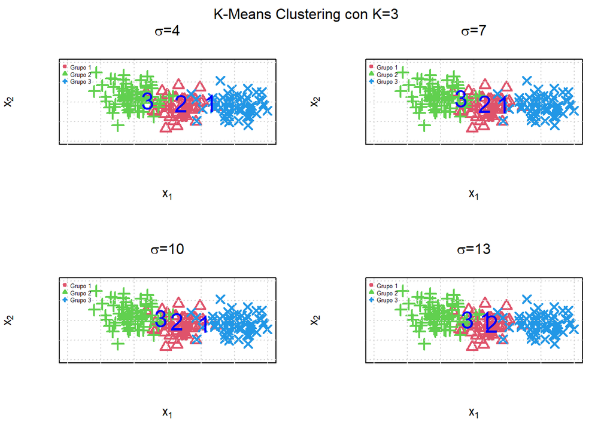

¿Qué pasa cuando la estabilidad de los centroides cuando la varianza de las variables que se suman a las variables originales aumenta?

Al igual que cuando se agregó la primera variable, también se puede observar que a medida que aumenta $\sigma$ los centroides son cada vez más inestables, en el plano 2d se observa como cada vez más se juntan los centroides.

#### Grafica de varianza intre-grupos

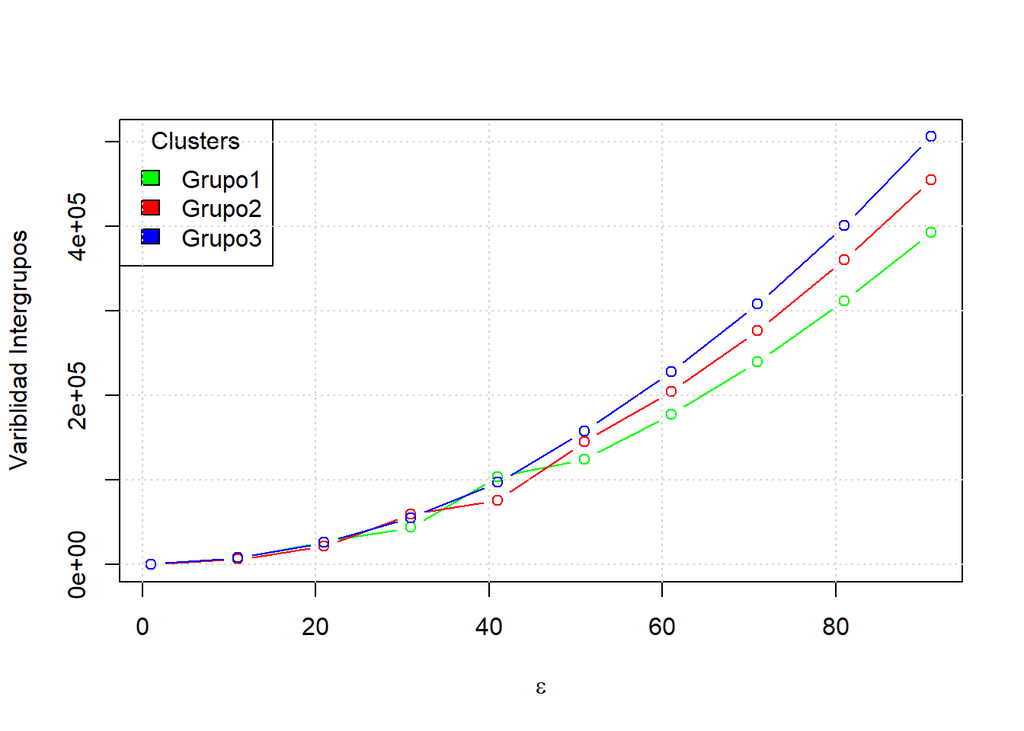

Aunque la variabilidad Inter-grupos si aumenta a medida que $\epsilon$ aumenta, para los tres grupos, la variabilidad aumenta de manera homogénea siendo muy parecida o no tan diferente, podemos afirmar de igual manera que los centroides no son estables.

5. A partir de estos experimentos, ¿qué se podría decir del efecto de la correlación entre variables y la estabilidad de los centroides en K-Medias?

Cuando se entrena un K-Means con variables correlacionadas, la metodología para hallar los centroides óptimos no converge de manera eficiente tal que reduzca la variabilidad entre los grupos, además de generar un costo computacional mayor hasta encontrar los puntos óptimos de los centroides, aun así como vemos en las simulaciones que agregar una variable correlacionada y con alta variabilidad tampoco permite converger a los centroides óptimos para el algoritmo.

### Bibliografia

- https://rpubs.com/Joaquin_AR/310338